# Quantile modelling of UK electricity demand: solution

```r
library(mgcViz); library(gridExtra)
data("UKload")
form <- NetDemand~s(wM,k=20,bs='cr') + s(wM_s95,k=20,bs='cr') +
        s(Posan, k=50, bs = "cr") + Dow + s(Trend,k=4,bs='cr') +
        NetDemand.48 + Holy
```

2. Fit model and plot smooths

```r
qu <- 0.5
fit <- qgamV(form = form, data = UKload, qu = qu, err = 0.1)
```

```
## Estimating learning rate. Each dot corresponds to a loss evaluation.
## qu = 0.5...............done
```

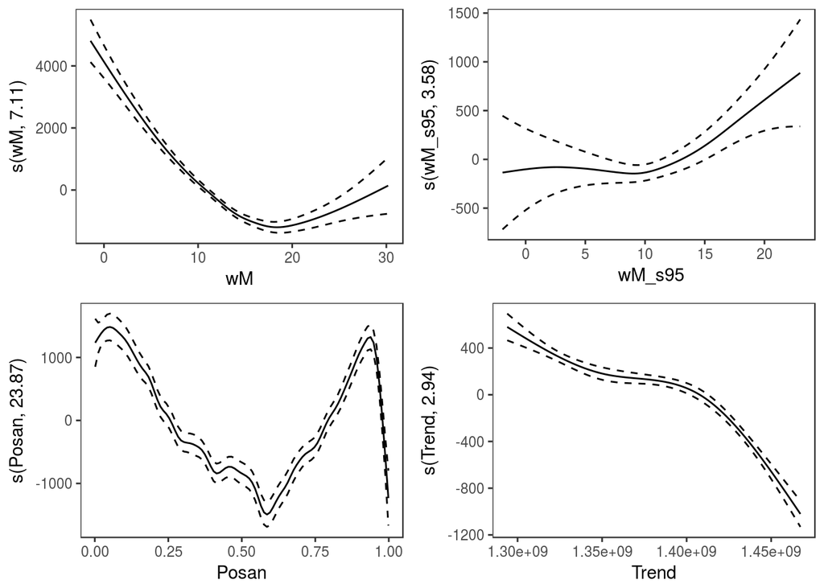

```r
print(plot(fit), pages = 1)
```

```r
summary(fit)
```

```
##
## Family: elf
## Link function: identity
##
## Formula:
## NetDemand ~ s(wM, k = 20, bs = "cr") + s(wM_s95, k = 20, bs = "cr") +
##     s(Posan, k = 50, bs = "cr") + Dow + s(Trend, k = 4, bs = "cr") +
##     NetDemand.48 + Holy
##
## Parametric coefficients:
##                Estimate Std. Error z value Pr(>|z|)
## (Intercept)   2.093e+04  5.445e+02   38.45   <2e-16 ***
## Dowjeudi      3.599e+03  9.733e+01   36.97   <2e-16 ***
## Dowlundi      6.149e+03  6.106e+01  100.71   <2e-16 ***
## Dowmardi      3.650e+03  1.009e+02   36.16   <2e-16 ***
## Dowmercredi   3.707e+03  9.639e+01   38.46   <2e-16 ***
## Dowsamedi    -1.667e+03  9.391e+01  -17.75   <2e-16 ***
## Dowvendredi   3.330e+03  9.675e+01   34.41   <2e-16 ***
## NetDemand.48  4.224e-01  1.461e-02   28.92   <2e-16 ***
## Holy1        -3.613e+03  3.056e+02  -11.82   <2e-16 ***
## ---
## Signif. codes:  0 '***' 0.001 '**' 0.01 '*' 0.05 '.' 0.1 ' ' 1
##
## Approximate significance of smooth terms:
##              edf Ref.df Chi.sq p-value
## s(wM)      7.109  8.733 339.95 < 2e-16 ***
## s(wM_s95)  3.581  4.743  18.65 0.00182 **
## s(Posan)  23.875 29.239 476.13 < 2e-16 ***
## s(Trend)   2.938  2.997 437.68 < 2e-16 ***
## ---
## Signif. codes:  0 '***' 0.001 '**' 0.01 '*' 0.05 '.' 0.1 ' ' 1
##
## R-sq.(adj) =  0.946   Deviance explained = 86.4%
## -REML =  16283  Scale est. = 1         n = 2008
```

The effect of `Posan` is fairly wiggly and drops sharply in the Christmas period.

3. Modify model formula and refit

```r
form <- NetDemand~s(wM,k=20,bs='cr') + s(wM_s95,k=20,bs='cr') +
        s(Posan, bs='ad', k=50) + Dow + s(Trend,k=4) +
        NetDemand.48 + Holy

fit <- qgamV(form = form, data = UKload, qu = qu, err = 0.1)
```

```
## Estimating learning rate. Each dot corresponds to a loss evaluation.
## qu = 0.5...............done
```

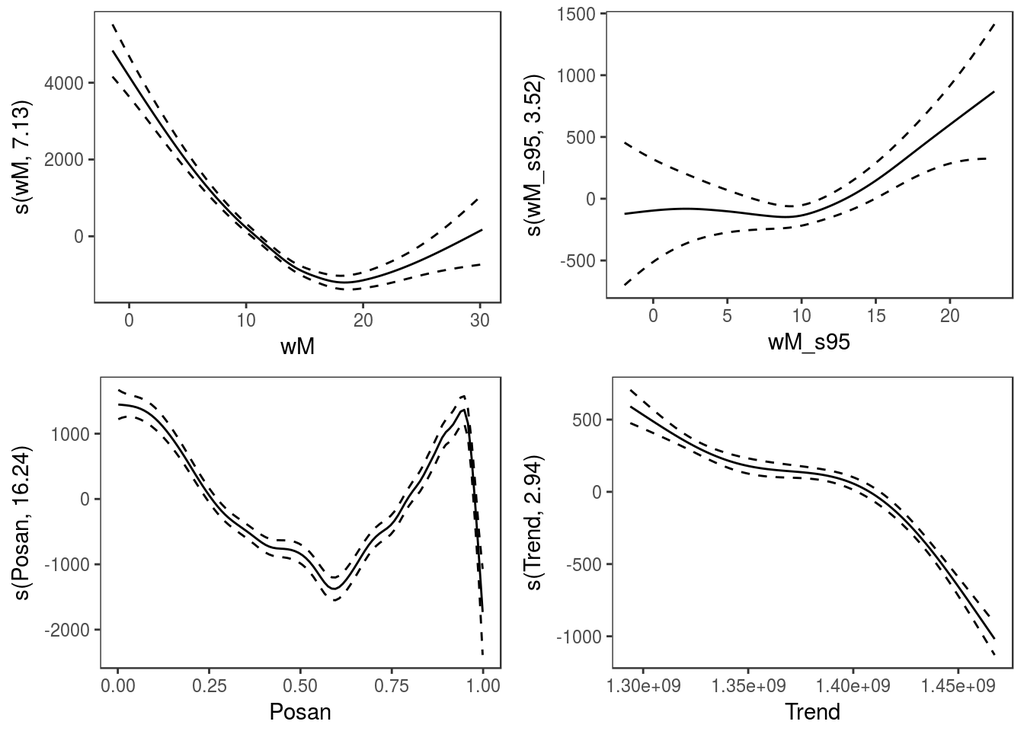

```r
print(plot(fit), pages = 1)
```

```r
summary(fit)
```

```
##
## Family: elf
## Link function: identity
##
## Formula:
## NetDemand ~ s(wM, k = 20, bs = "cr") + s(wM_s95, k = 20, bs = "cr") +
##     s(Posan, bs = "ad", k = 50) + Dow + s(Trend, k = 4) + NetDemand.48 +
##     Holy
##
## Parametric coefficients:
##                Estimate Std. Error z value Pr(>|z|)
## (Intercept)   2.084e+04  5.486e+02   37.99   <2e-16 ***
## Dowjeudi      3.588e+03  9.842e+01   36.46   <2e-16 ***
## Dowlundi      6.152e+03  6.102e+01  100.82   <2e-16 ***
## Dowmardi      3.646e+03  1.016e+02   35.88   <2e-16 ***
## Dowmercredi   3.699e+03  9.796e+01   37.76   <2e-16 ***
## Dowsamedi    -1.678e+03  9.470e+01  -17.72   <2e-16 ***
## Dowvendredi   3.320e+03  9.764e+01   34.00   <2e-16 ***
## NetDemand.48  4.246e-01  1.472e-02   28.85   <2e-16 ***
## Holy1        -3.455e+03  3.007e+02  -11.49   <2e-16 ***
## ---
## Signif. codes:  0 '***' 0.001 '**' 0.01 '*' 0.05 '.' 0.1 ' ' 1
##
## Approximate significance of smooth terms:
##              edf Ref.df Chi.sq p-value
## s(wM)      7.134  8.762  343.4 < 2e-16 ***
## s(wM_s95)  3.517  4.661   18.2 0.00207 **
## s(Posan)  16.241 19.613  476.9 < 2e-16 ***
## s(Trend)   2.940  2.997  430.7 < 2e-16 ***
## ---
## Signif. codes:  0 '***' 0.001 '**' 0.01 '*' 0.05 '.' 0.1 ' ' 1
##
## R-sq.(adj) =  0.946   Deviance explained = 86.4%
## -REML =  16270  Scale est. = 1         n = 2008
```

Now the effect of `Posan` is smoother along most of the year, but it drops around Christmas even more than before. This is because many businesses are shut and people go on holiday during this period. An adaptive basis makes so that we use lots of degrees of freedom where they are needed (winter holiday) and few where the effect is smooth. Alternatively, we could have added a factor for the winter period (although one might point out that we have already included a dummy variable indicating bank holidays).

4. mqgam fit and plotting effects for each quantile

```r
nqu <- 5
qus <- seq(0.1, 0.9, length.out = nqu)
fitM <- mqgamV(form = form, data = UKload, err = 0.1, qu = qus)
```

```
## Estimating learning rate. Each dot corresponds to a loss evaluation.
## qu = 0.5...............done
## qu = 0.3............done
## qu = 0.7..............done
## qu = 0.1...........done
## qu = 0.9.............done
```

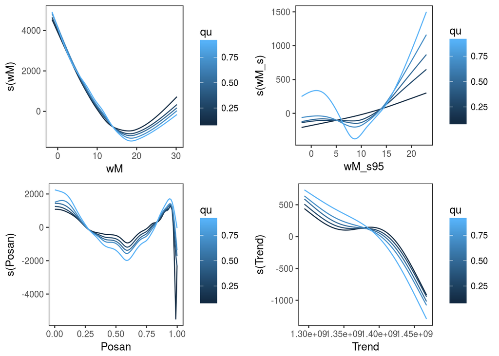

```r
print(plot(fitM), pages = 1)
```

Notice that when the effects of low and high quantiles diverge, the conditional variance of the response is increasing (other things being equal). Along `wM_s95` we can also see that at low temperatures the load distribution is skewed to the right (again, other things being equal). Looking at the plot for `Posan`, look at how the Christmas effect changes depending on the quantile. The lowest quantiles, are more strongly effected: they go down and then bounce back. We couldn’t get such insights with a Gaussian GAM!

We can also look at the parametric effects:

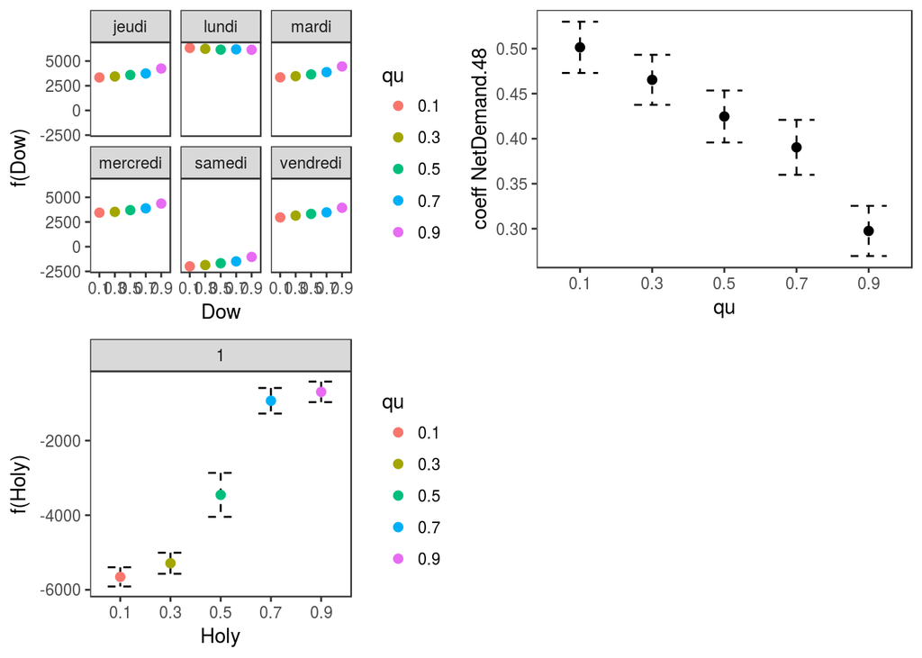

```r
print(plot(fitM, allTerms = T, select = 5:7), pages = 1)
```

It is interesting to notice that the holiday effect is stronger (more negative) on the low quantiles.

7. Model checking

We consider the third quantile (the median), first we look at the bias caused by smooth the loss:

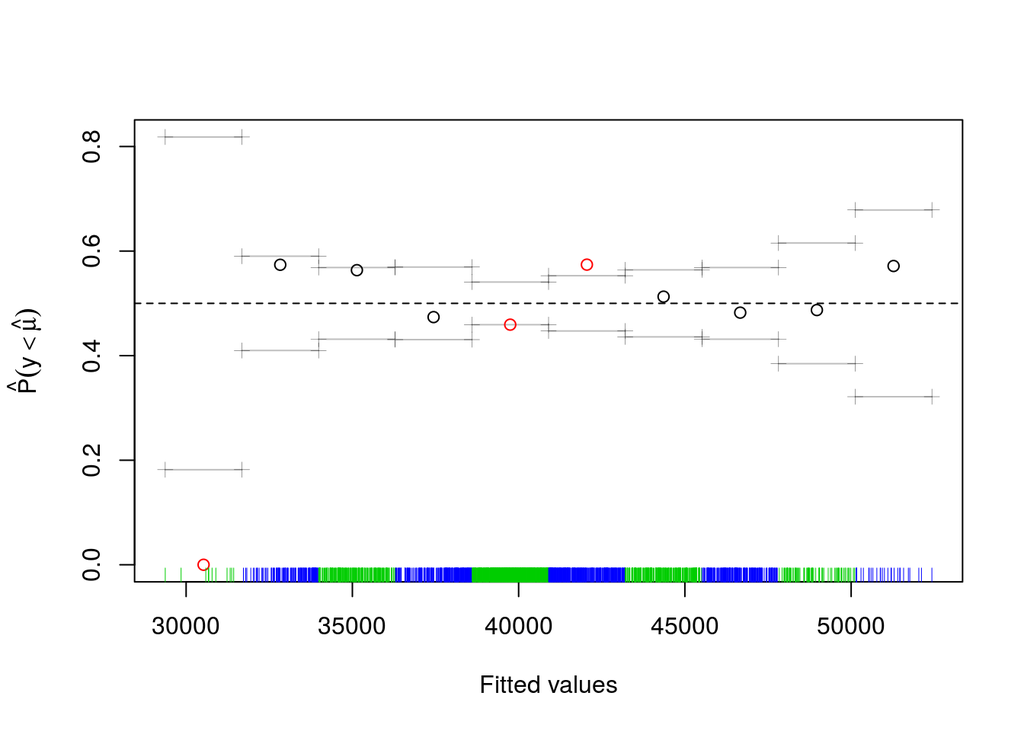

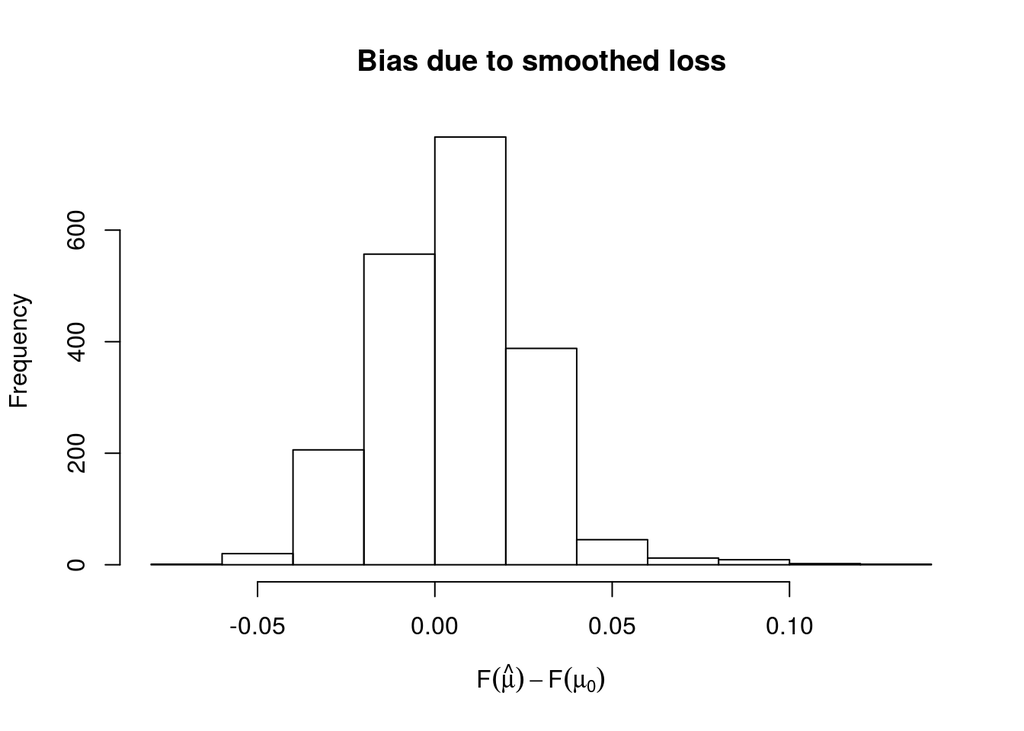

```
## Theor. proportion of neg. resid.: 0.5   Actual proportion: 0.5054781
## Integrated absolute bias |F(mu) - F(mu0)| = 0.01666654
## Method: REML   Optimizer: outer newton
## full convergence after 6 iterations.
## Gradient range [-0.001338773,0.004266521]
## (score 16270.07 & scale 1).
## Hessian positive definite, eigenvalue range [0.0001173881,3.101468].
## Model rank =  99 / 99
##
## Basis dimension (k) check: if edf is close too k' (maximum possible edf)
## it might be worth increasing k.
##
##           k'   edf
## s(wM)     19  7.13
## s(wM_s95) 19  3.52
## s(Posan)  49 16.24
## s(Trend)   3  2.94
```

```r
indx <- 3
check(fitM[[indx]])
```

These checks mostly focus on the fraction of residuals falling below the fitted quantile, which should be close to 0.5 given that we are fitting quantile $\tau = 0.5$.

We can also verify whether the fraction of points falling below the fit depart too much from $\tau = 0.5$, along each covariate:

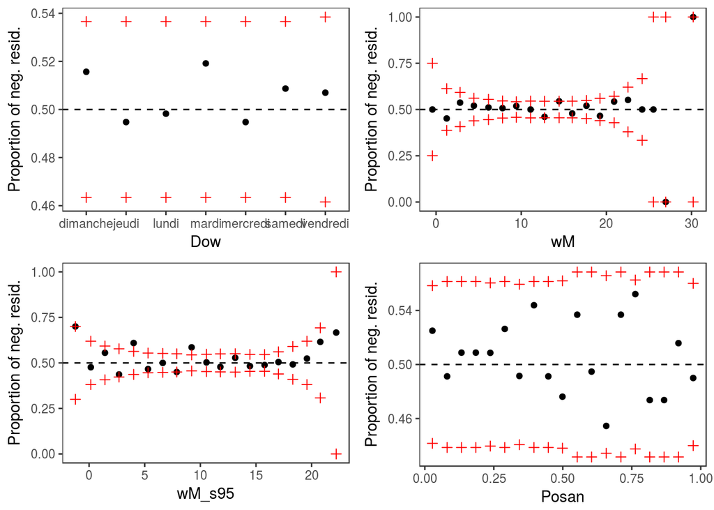

```r
pl <- list()
pl[[1]] <- check1D(fitM[[indx]], x = "Dow") + l_gridQCheck1D(qu = qus[indx])
pl[[2]] <- check1D(fitM[[indx]], x = "wM") + l_gridQCheck1D(qu = qus[indx])
pl[[3]] <- check1D(fitM[[indx]], x = "wM_s95") + l_gridQCheck1D(qu = qus[indx])
pl[[4]] <- check1D(fitM[[indx]], x = "Posan") + l_gridQCheck1D(qu = qus[indx])

# To plot using grid.arrange, we need to extract the ggplot objects
library(gridExtra)
grid.arrange(grobs = lapply(pl, "[[", 1))
```

Looks good, most departures are within 80 percent confidence bands.